# Homework 3

Mari Sanders

2025-02-20

# Data

```r
data <- read_delim("moreno_oz/out.moreno_oz_oz", skip = 1) %>% select(1:3)
```

# Graphing Model

This is a weighted graph, which contains friendship ratings between 217 residents living at a residence hall located on the Australian National University campus.

Each node represents a person and each edge represents the friendship between the two nodes.

```r
edge_list <- data %>% select(1:2) %>% as.data.frame()
g <- graph_from_data_frame(edge_list)
E(g)$weight <- data %>% select(3) %>% pull()
summary(g)
```

```
## IGRAPH b3cd91f DNW- 217 2672 --
## + attr: name (v/c), weight (e/n)
```

# Graphics

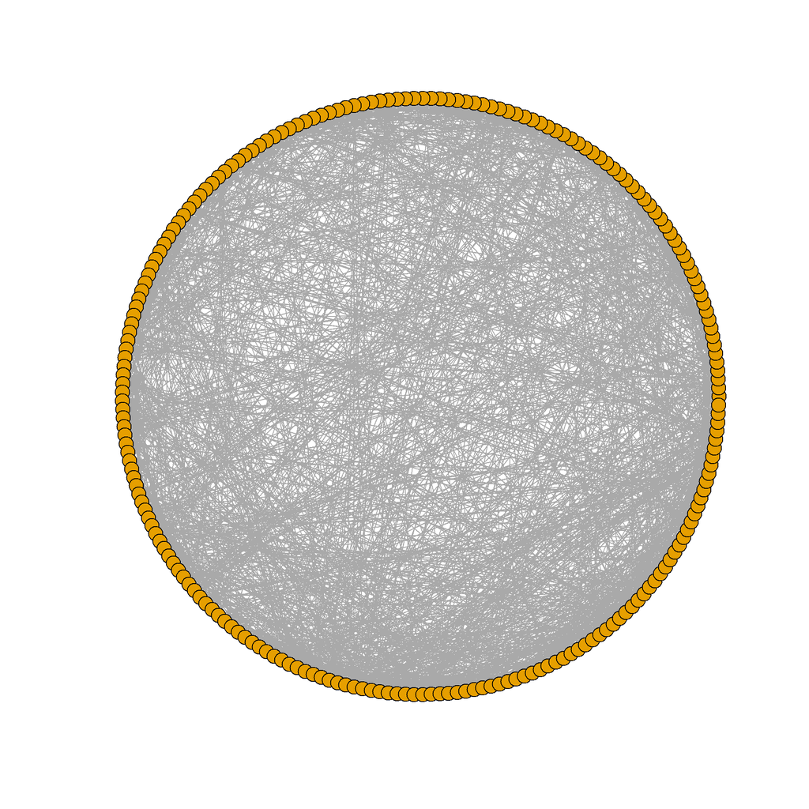

```r
igraph_options(vertex.size=5, vertex.label=NA, edge.arrow.size=0.5)
plot(g, layout = layout_in_circle)
```

This type of graph does not seem to represent it well, as it is difficult to see all the edges in the graph.

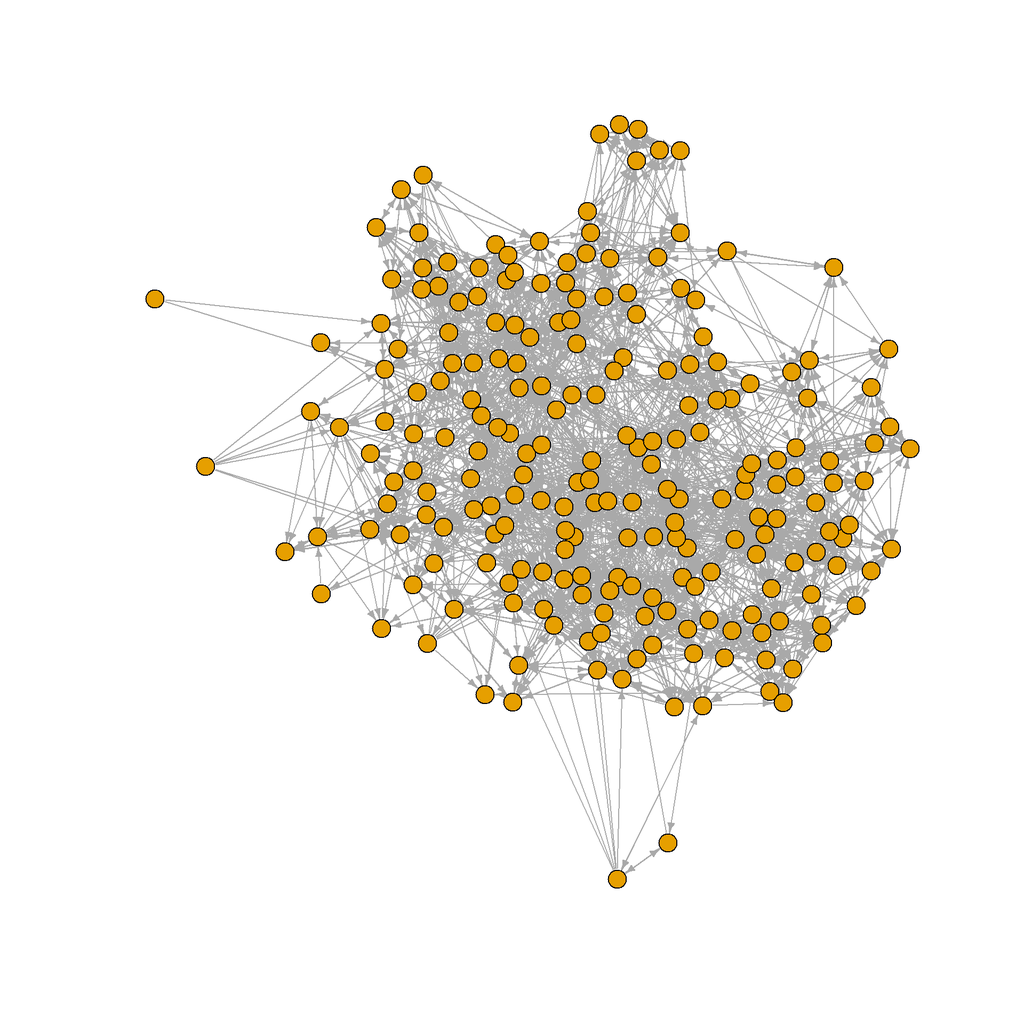

```r
igraph_options(vertex.size=5, vertex.label=NA, edge.arrow.size=0.5)
plot(g, layout = layout_with_fr)
```

This improved upon the circular graph, but it is still a bit difficult to see all the edges in the middle of the graph. It is easier to see the connections on the outside of the graph, but not the middle.

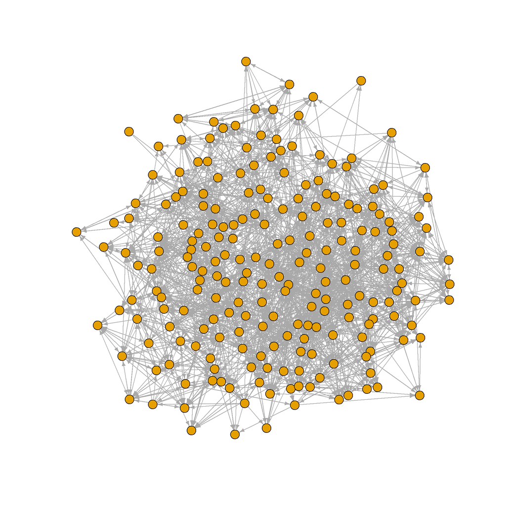

```r
igraph_options(vertex.size=5, vertex.label=NA, edge.arrow.size=0.5)
plot(g, layout=layout_with_kk)
```

This is pretty similar to the above graph, where it is easy to see the connections on the outside, but not in the middle.

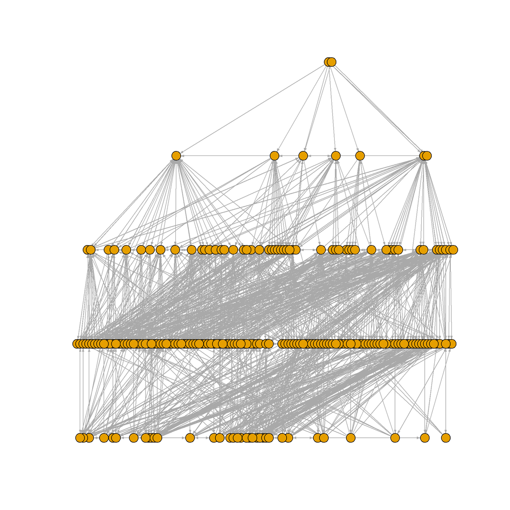

```r
igraph_options(vertex.size=5, vertex.label=NA, edge.arrow.size=0.3)
plot(g, layout = layout_as_tree)
```

This actually isn’t a terrible representation, but doesn’t make sense for a traditional tree structure. Normally the direction of trees is only one way and this is not the case with the features of this graph.

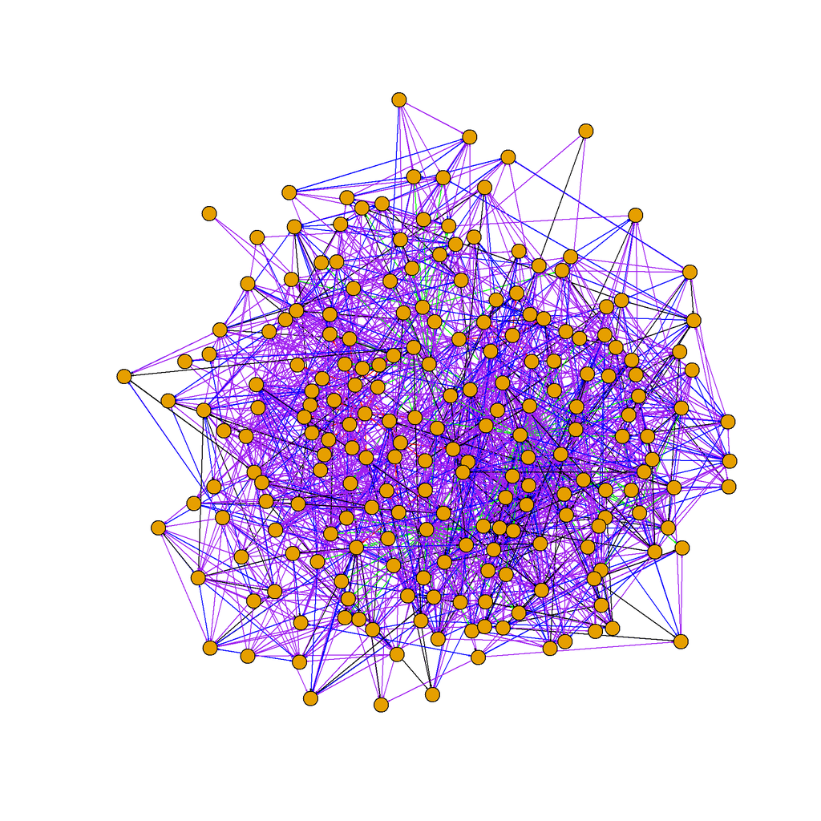

```r
igraph_options(vertex.size=5, vertex.label=NA, edge.arrow.size=0.1)
E(g)$color[E(g)$weight == 1] <- "red"
E(g)$color[E(g)$weight == 2] <- "green"
E(g)$color[E(g)$weight == 3] <- "purple"
E(g)$color[E(g)$weight == 4] <- "blue"
E(g)$color[E(g)$weight == 5] <- "black"

plot(g, layout = layout_with_kk)
```

In conclusion, I think that from this exploration, it is hard to visualize data with a lot of links that don’t have very specific groups. If it had been data where there were defined groups, you could split up the graph and graph multiple to get a better visualization.